# Shrinkage Estimators vis Stein-James

Matt Richey

October 12, 2016

Load the libraries

```r
library(ggplot2)
library(dplyr)
library(tidyr)
```

Data from the classic Efron/Morris paper on Shrinkage Estimators Data Analysis Using Stein’s Estimator and its Generalizations http://www.stat.cmu.edu/~acthomas/724/Efron-Morris.pdf

Baseball players go up to hit (an “At Bat”): sometimes they succeed, sometimes they fail. The proportion of successes is called the “batting average”. It is a estimate of the player’s “true” probability of success

The original data set from the paper. Eighteen players, each with exactly 90 at bats. Players include Roberto Clemente, Frank Robinson, Frank Howard, Ron Santo, Bert Campaneris, and Thurman Munson

```r
bb.df <- read.csv("baseball.txt",sep=" ")
bb.df
```

```
##    Player   MLE TRUTH
## 1       1 0.345 0.298
## 2       2 0.333 0.346
## 3       3 0.322 0.222
## 4       4 0.311 0.276
## 5       5 0.289 0.263
## 6       6 0.289 0.273
## 7       7 0.278 0.303
## 8       8 0.255 0.270
## 9       9 0.244 0.230
## 10     10 0.233 0.264
## 11     11 0.233 0.264
## 12     12 0.222 0.210
## 13     13 0.222 0.256
## 14     14 0.222 0.269
## 15     15 0.211 0.316
## 16     16 0.211 0.226
## 17     17 0.200 0.285
## 18     18 0.145 0.200
```

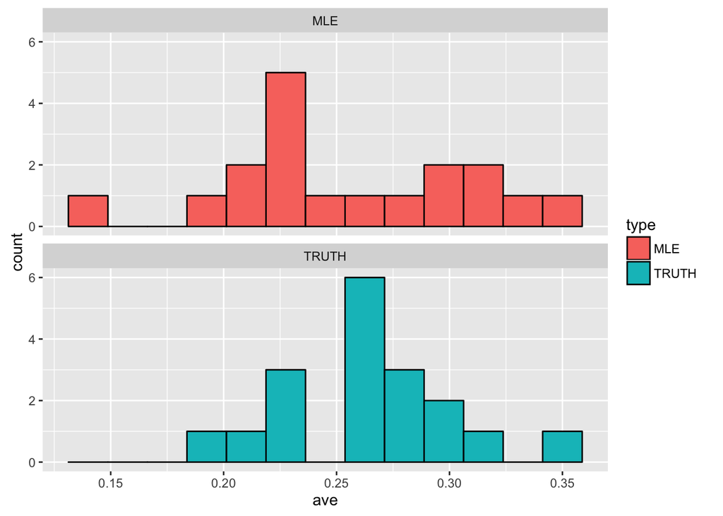

```r
bb.df%>%
    select(Player,MLE,TRUTH)%>%
    gather(type,ave,MLE:TRUTH,-Player)%>%
    ggplot(aes(ave,fill=type))+
    geom_histogram(color="black",binwidth=.0175)+
    facet_wrap(~type,ncol=1)
```

Another strategy is to assume all the players are identical and we are just seeing random variation amoung the success rates. Hence, the best estimate for each player is just the pooled proportion of sucess.

Stein-James says the best individual estimator for each player is a compromise between these to estimators.

Get to work The number at bats (common to all).

```r
AB0 <- 90
```

The key quantities. * M is Total number of observations. In this case, 18 * pbar=pooled average * sigma0 =estimated variance of of the pbar. * perr=estimated standard error (or so)

```r
M <- nrow(bb.df)
(pbar <- with(bb.df,mean(MLE)))
```

```
## [1] 0.2536111
```

```r
(sigma0 <- pbar*(1-pbar)/AB0)
```

```
## [1] 0.00210325
```

```r
(perr <- with(bb.df,sum( (MLE-pbar)^2)))
```

```
## [1] 0.04796828
```

```r
sigma0/perr
```

```
## [1] 0.04384669
```

The key quantity the shrinkage factor

```r
(shrinkJS <- 1-(M-3)*sigma0/perr)
```

```
## [1] 0.3422997
```

```r
bb.df <- bb.df%>%
    mutate(JS = pbar+shrinkJS*(MLE-pbar))
bb.df
```

```
##    Player   MLE TRUTH        JS
## 1       1 0.345 0.298 0.2848935
## 2       2 0.333 0.346 0.2807859
## 3       3 0.322 0.222 0.2770206
## 4       4 0.311 0.276 0.2732553
## 5       5 0.289 0.263 0.2657247
## 6       6 0.289 0.273 0.2657247
## 7       7 0.278 0.303 0.2619594
## 8       8 0.255 0.270 0.2540865
## 9       9 0.244 0.230 0.2503212
## 10     10 0.233 0.264 0.2465559
## 11     11 0.233 0.264 0.2465559
## 12     12 0.222 0.210 0.2427906
## 13     13 0.222 0.256 0.2427906
## 14     14 0.222 0.269 0.2427906
## 15     15 0.211 0.316 0.2390253
## 16     16 0.211 0.226 0.2390253
## 17     17 0.200 0.285 0.2352600
## 18     18 0.145 0.200 0.2164336
```

A picture of the shrinkage

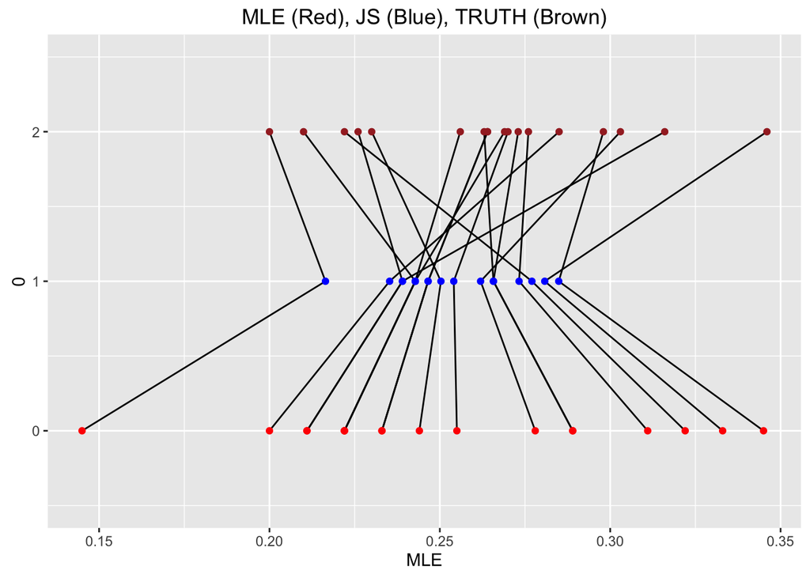

```r
ggplot(bb.df) +
    geom_segment(aes(x=MLE,xend=JS,y=0,yend=1))+
    geom_segment(aes(x=TRUTH,xend=JS,y=2,yend=1))+
    geom_point(aes(x=MLE,y=0),color="red")+
    geom_point(aes(x=TRUTH,y=2),color="brown") +
    geom_point(aes(x=JS,y=1),color="blue")  +
    scale_y_continuous(limits=c(-0.5,2.5))+
    ggtitle("MLE (Red), JS (Blue), TRUTH (Brown)")
```

Loss functions: Pooled, MLE, and JS

```r
lossPOOL <- with(bb.df,sum( (TRUTH-pbar)^2))
lossMLE <- with(bb.df,sum( (TRUTH-MLE)^2))
lossJS <- with(bb.df,sum( (TRUTH-JS)^2))
c(lossPOOL,lossMLE,lossJS)
```

```
## [1] 0.02661050 0.04251200 0.02125445
```

# Repeat all this on Current Data

```r
dir <- "/Users/richeym/Dropbox/WORK/SPORTS/BASEBALL/DATA/CSV_DATA"
fileName <- "gameDataProcessed_2013.csv"
file <- sprintf("%s/%s",dir,fileName)
bbUpdate.df <- read.csv(file)
names(bbUpdate.df)
```

```
##  [1] "outs"        "ONBASE"      "topbot"      "run.diff"    "Inning"
##  [6] "gid"         "hTeam"       "vTeam"       "batterID"    "pitcherID"
## [11] "inning"      "vruns"       "hruns"       "R1"          "R2"
## [16] "R3"          "event"       "idx"         "lateInning"  "STATUS"
## [21] "runs"        "won"         "HWIN"        "inningFac"   "batterTeam"
## [26] "pitcherTeam" "date"        "maxRuns"     "futureRuns"  "prob.emp"
## [31] "prob.er"     "prob.glm"    "er"
```

Events are what happened during an AB

```r
(events <- with(bbUpdate.df,sort(unique(event))))
```

```
##  [1] Balk                     Batter Interference
##  [3] Bunt Groundout           Bunt Lineout
##  [5] Bunt Pop Out             Catcher Interference
##  [7] Caught Stealing 2B       Caught Stealing 3B
##  [9] Caught Stealing Home     Defensive Indiff
## [11] Double                   Double Play
## [13] Error                    Fan interference
## [15] Field Error              Fielders Choice
## [17] Fielders Choice Out      Flyout
## [19] Forceout                 Grounded Into DP
## [21] Groundout                Hit By Pitch
## [23] Home Run                 Intent Walk
## [25] LEADOFF                  Lineout
## [27] Passed Ball              Picked off stealing 2B
## [29] Picked off stealing 3B   Picked off stealing home
## [31] Pickoff 1B               Pickoff 2B
## [33] Pickoff 3B               Pickoff Error 1B
## [35] Pickoff Error 2B         Pickoff Error 3B
## [37] Pop Out                  Runner Interference
## [39] Runner Out               Sac Bunt
## [41] Sac Fly                  Sac Fly DP
## [43] Sacrifice Bunt DP        Single
## [45] Stolen Base 2B           Stolen Base 3B
## [47] Stolen Base Home         Strikeout
## [49] Strikeout - DP           Triple
## [51] Triple Play              Walk
## [53] Wild Pitch
## 53 Levels: Balk Batter Interference Bunt Groundout ... Wild Pitch
```

These are the ones that count as ABs

```r
event.ids <- which(events %in% c("Strikeout","Lineout","Groundout","Flyout",
                                 "Pop Out","Forceout","Double Play","Strikeout - DP",
                                 "Bunt Groundout","Bunt Lineout","Bunt Popout",
                                 "Fielders Choice Out", "Fielders Choice",
                                 "Single","Double","Triple","Home Run"))
(abEvents <- droplevels(events[event.ids]))
```

```
##  [1] Bunt Groundout      Bunt Lineout        Double
##  [4] Double Play         Fielders Choice     Fielders Choice Out
##  [7] Flyout              Forceout            Groundout
## [10] Home Run            Lineout             Pop Out
## [13] Single              Strikeout           Strikeout - DP
## [16] Triple
## 16 Levels: Bunt Groundout Bunt Lineout Double ... Triple
```

Filter on these

```r
absUpdate.df <- bbUpdate.df%>%
    filter(event %in%abEvents)
```

Only consider batters with a reasonable number of ABs

```r
batterTots.df <- absUpdate.df%>%
    group_by(batterID)%>%
    summarize(AB=n())%>%
    filter(AB>375)
```

Get the player IDs and take a random sample for our experiment

```r
playerIDs <- with(batterTots.df,unique(batterID))
playerIDs <- sample(playerIDs,40,rep=F)
```

filter on these players and only keep relevent variables

```r
absUpdate.df2 <- absUpdate.df%>%
    filter(batterID %in% playerIDs)%>%
    arrange(batterID,gid,inning)%>%
    select(batterID,event)%>%
    group_by(batterID)
```

Now grab all the hits and create a hit indicator Then create a running total of abs, hits and average

```r
hit.ids <- which(events %in% c("Single","Double","Triple","Home Run"))
(hitEvents <- droplevels(events[hit.ids]))
```

```
## [1] Double   Home Run Single   Triple
## Levels: Double Home Run Single Triple
```

```r
absUpdate.df2 <- absUpdate.df2%>%
    mutate(HIT=event %in% hitEvents)%>%
    mutate(abNum=row_number(),
           hitNum=cumsum(HIT),
           aveCurr=hitNum/abNum)
head(absUpdate.df2)
```

```
## Source: local data frame [6 x 6]
## Groups: batterID [1]
##
##   batterID     event   HIT abNum hitNum aveCurr
##      <int>    <fctr> <lgl> <int>  <int>   <dbl>
## 1   117244   Lineout FALSE     1      0       0
## 2   117244    Flyout FALSE     2      0       0
## 3   117244    Flyout FALSE     3      0       0
## 4   117244    Flyout FALSE     4      0       0
## 5   117244 Groundout FALSE     5      0       0
## 6   117244 Strikeout FALSE     6      0       0
```

Filter on AB0 at bats

```r
absAB0.df <- absUpdate.df2%>%
    filter(abNum==AB0)%>%
    select(batterID,aveCurr,hitNum)
```

Filter on last at bats

```r
absLast.df <- absUpdate.df2%>%
    group_by(batterID)%>%
    filter(row_number()==n())%>%
    select(batterID,aveCurr,abNum,hitNum)
```

Rename

```r
names(absLast.df)[2:4] <- c("aveFinal","abFinal","hitFinal")
```

Join these together…this is the updated version of the original data set

```r
bbUpdate.df <- absAB0.df%>%
    inner_join(absLast.df)%>%
    mutate(aveRest=(hitFinal-hitNum)/(abFinal-AB0))%>%
    ungroup()
names(bbUpdate.df)[c(1,2,7)] <- c("Player","MLE","TRUTH")
```

A look at the dispersal of averages

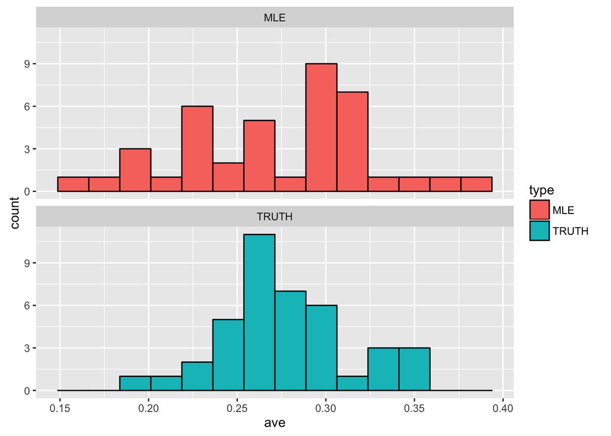

```r
bbUpdate.df%>%
    select(Player,MLE,TRUTH)%>%
    gather(type,ave,MLE:TRUTH,-Player)%>%
    ggplot(aes(ave,fill=type))+
    geom_histogram(color="black",binwidth=.0175)+
    facet_wrap(~type,ncol=1)
```

Compute these values for the James-Stein Estimator

```r
(M <- nrow(bbUpdate.df))
```

```
## [1] 40
```

```r
(pbar <- with(bbUpdate.df,mean(MLE)))
```

```
## [1] 0.2716667
```

```r
(perr <- with(bbUpdate.df,sum( (MLE-pbar)^2)))
```

```
## [1] 0.1029506
```

```r
(sigma0 <- pbar*(1-pbar)/AB0)
```

```
## [1] 0.002198488
```

```r
(K <- (M-3)*sigma0/perr)
```

```
## [1] 0.7901268
```

```r
(shrinkJS <- 1-K)
```

```
## [1] 0.2098732
```

The JS estimator of the TRUE average

```r
bbUpdate.df <- bbUpdate.df%>%
    mutate(JS = pbar+shrinkJS*(MLE-pbar))
```

How do the shrinkage estimators look??

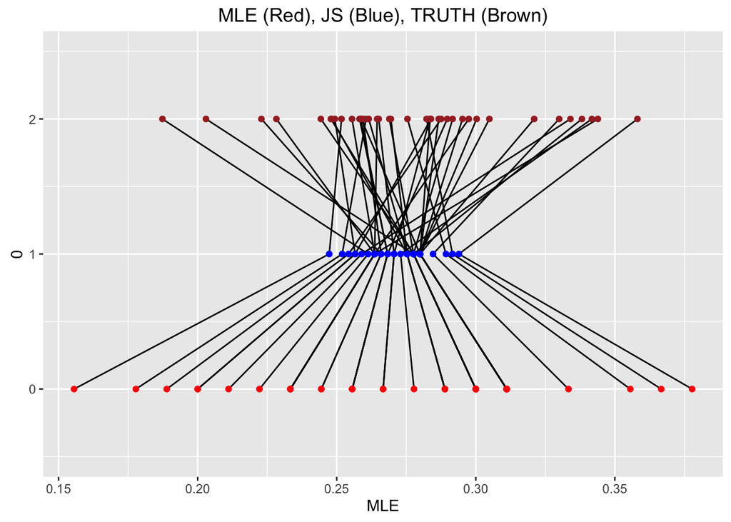

```r
ggplot(bbUpdate.df) +
    geom_segment(aes(x=MLE,xend=JS,y=0,yend=1))+
    geom_segment(aes(x=TRUTH,xend=JS,y=2,yend=1))+
    geom_point(aes(x=MLE,y=0),color="red")+
    geom_point(aes(x=TRUTH,y=2),color="brown") +
    geom_point(aes(x=JS,y=1),color="blue")  +
    scale_y_continuous(limits=c(-0.5,2.5))+
    ggtitle("MLE (Red), JS (Blue), TRUTH (Brown)")
```

Loss functions: Pooled, MLE, and JS

```r
lossPOOL <- with(bbUpdate.df,sum( (TRUTH-pbar)^2))
lossMLE <- with(bbUpdate.df,sum( (TRUTH-MLE)^2))
lossJS <- with(bbUpdate.df,sum( (TRUTH-JS)^2))
```

compare loss functions

```r
c(lossPOOL,lossMLE,lossJS)
```

```
## [1] 0.05675398 0.11473114 0.05184990
```